# The effects of different ratio and particle size combination of waste limestone on AMD

2023-06-17

For this analysis, we will use mixed models to analyze the effect of ratio and particle size in treating acid mine drainage using repeated measures anova to determine differences between treatments. We shall also use anova to determine if any of the treatment combinations have an effect on the iron content of the AMD.

```r
library(lme4)
library(readxl)
library(lmerTest)
library(flexplot)
library(car)
library(DescTools)
library(multcomp)
library(MASS)
library(glmertree)
library(performance)
library(lsmeans)
```

# Loading the data for pH level analysis

```r
setwd("C:/Users/jairu/Documents")

#ph data
ph_data <- read_excel("phLevel_data.xlsx")
ph_data$size <- as.factor(ph_data$size)
ph_data$ratio <- as.factor(ph_data$ratio)
ph_data$id <- as.factor(ph_data$id)
head(ph_data)
```

```
## # A tibble: 6 × 5
##   id    size  ratio         time ph_level
##   <fct> <fct> <fct>        <dbl>    <dbl>
## 1 1     0.5   0:100 (lime)     0     3.69
## 2 1     0.5   0:100 (lime)    30     5.61
## 3 1     0.5   0:100 (lime)    60     6.4
## 4 1     0.5   0:100 (lime)    90     7.57
## 5 1     0.5   0:100 (lime)   120     8.47
## 6 1     0.5   0:100 (lime)   150     8.87
```

Here we have a longitudinal data where each row corresponds to an observation on a certain particle size and ratio taken at a certain instance of time.

# Loading the data for iron content analysis

```r
iron_data <- read_excel("ironContent_data_new.xlsx")
iron_data$size <- as.factor(iron_data$size)
iron_data$ratio <- as.factor(iron_data$ratio)
head(iron_data)
```

```
## # A tibble: 6 × 3
##   size  ratio iron_content
##   <fct> <fct>        <dbl>
## 1 #30   100:0          0.9
## 2 #30   75:25          0.8
## 3 #30   50:50          0.8
## 4 #30   25:75          0.8
## 5 #60   100:0          0.8
## 6 #60   75:25          0.9
```

# Linear Mixed Model for pH Level

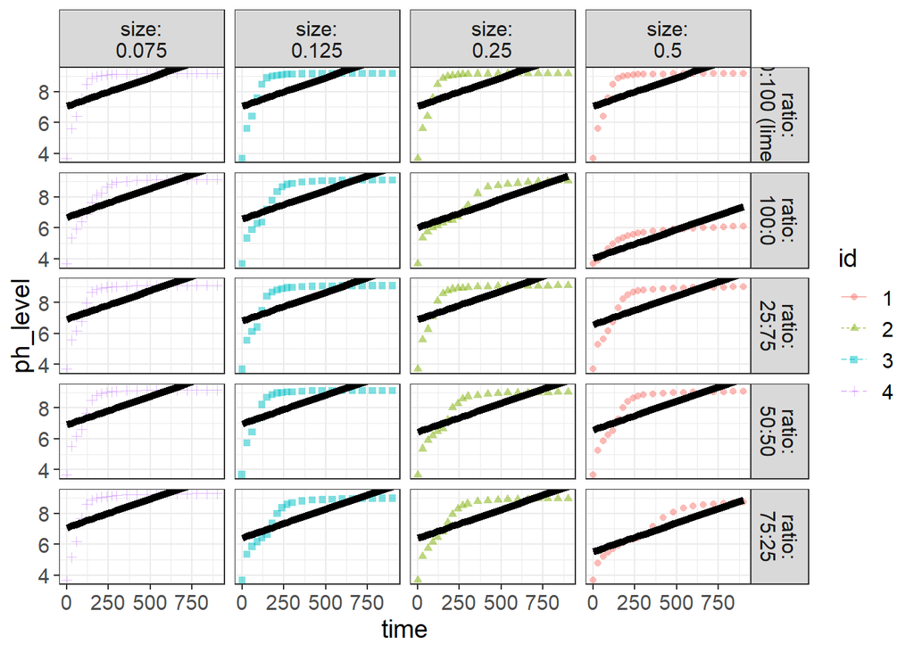

```r
lmMod <- lmer(ph_level ~ time + size * ratio + (1|id), data=ph_data)
visualize(lmMod, plot="model", sample=5)
```

*Note that the particle size does not apply to the pure lime treatment. Data is specified this way to be able to produce comparisons between the control group and the treatment groups on each level of the size and ratio variables.

To compare the different treatment levels to each other, I have combine the size and ratio variables into one variable called ‘sr’. For this, we have data and model below:

```r
ph_data2 <- read_excel("combined_vars.xlsx")
ph_data2$sr <- as.factor(ph_data2$sr)
ph_data2$id <- as.factor(ph_data2$id)
head(ph_data2)
```

```
## # A tibble: 6 × 4
##   id    sr            time ph_level
##   <fct> <fct>        <dbl>    <dbl>
## 1 1     control&lime     0     3.69
## 2 1     control&lime    30     5.61
## 3 1     control&lime    60     6.4
## 4 1     control&lime    90     7.57
## 5 1     control&lime   120     8.47
## 6 1     control&lime   150     8.87
```

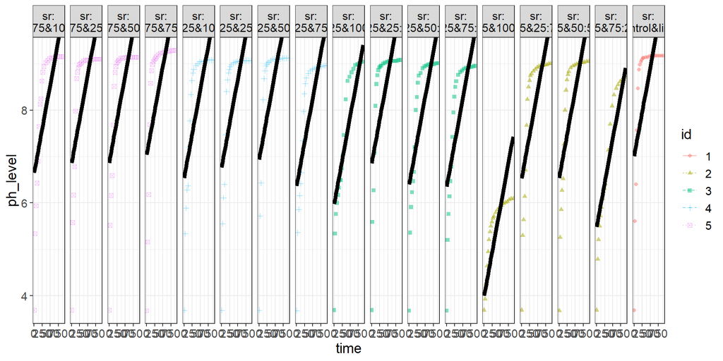

```r
lmMod2 <- lmer(ph_level ~ time + sr + (1|id), data=ph_data2)
visualize(lmMod2, plot="model", sample = 5)
```

Above is the data per ratio and size combination along with the slope of the model.

For this mixed model, an additional variable “id” is used as a clustering variable to account for the different particle sizes used in the experiment. ID = 1 pertains to the size of the pure lime or control group. ID = 2 is for 0.5mm, ID = 3 is for 0.25mm, ID = 4 is for 0.125mm and ID = 5 is for 0.075mm

```r
summary(lmMod2)
```

```
## Linear mixed model fit by REML. t-tests use Satterthwaite's method [
## lmerModLmerTest]
## Formula: ph_level ~ time + sr + (1 | id)
##    Data: ph_data2
##
## REML criterion at convergence: 1044
##
## Scaled residuals:
##     Min      1Q  Median      3Q     Max
## -3.2935 -0.5925  0.0854  0.7857  1.2620
##
## Random effects:
##  Groups   Name        Variance Std.Dev.
##  id       (Intercept) 0.2956   0.5437
##  Residual             1.0395   1.0195
## Number of obs: 357, groups:  id, 5
##
## Fixed effects:
##                  Estimate Std. Error         df t value Pr(>|t|)
## (Intercept)     6.648e+00  5.921e-01  3.390e+02  11.228  < 2e-16 ***
## time            3.814e-03  1.953e-04  3.390e+02  19.530  < 2e-16 ***
## sr0.075&25:75   2.176e-01  3.146e-01  3.390e+02   0.692  0.48963
## sr0.075&50:50   2.138e-01  3.146e-01  3.390e+02   0.680  0.49726
## sr0.075&75:25   3.900e-01  3.146e-01  3.390e+02   1.240  0.21601
## sr0.125&100:0  -1.071e-01  8.307e-01  3.390e+02  -0.129  0.89746
## sr0.125&25:75   1.195e-01  8.307e-01  3.390e+02   0.144  0.88568
## sr0.125&50:50   2.843e-01  8.307e-01  3.390e+02   0.342  0.73241
## sr0.125&75:25  -2.762e-01  8.307e-01  3.390e+02  -0.332  0.73975
## sr0.25&100:0   -6.714e-01  8.307e-01  3.390e+02  -0.808  0.41953
## sr0.25&25:75    2.048e-01  8.307e-01  3.390e+02   0.246  0.80546
## sr0.25&50:50   -2.490e-01  8.307e-01  3.390e+02  -0.300  0.76452
## sr0.25&75:25   -2.962e-01  8.307e-01  3.390e+02  -0.357  0.72166
## sr0.5&100:0    -2.648e+00  8.307e-01  3.390e+02  -3.188  0.00157 **
## sr0.5&25:75    -1.157e-01  8.307e-01  3.390e+02  -0.139  0.88930
## sr0.5&50:50    -1.129e-01  8.307e-01  3.390e+02  -0.136  0.89202
## sr0.5&75:25    -1.166e+00  8.307e-01  3.390e+02  -1.404  0.16130
## srcontrol&lime  3.633e-01  8.307e-01  3.390e+02   0.437  0.66213
## ---
## Signif. codes:  0 '***' 0.001 '**' 0.01 '*' 0.05 '.' 0.1 ' ' 1
```

#### **Main effects:**

To interpret the main effects, we add the estimate of the ratio and size combination to the intercept. For example, if we want to estimate the ph level at 0.5mm size and 75:25 ratio and ignoring time, we have 6.648 + (-1.166) = 5.482

In summary, we just add the the estimate to the intercept to get the estimated pH level.

## ANOVA

```r
anova(lmMod2)
```

```
## Type III Analysis of Variance Table with Satterthwaite's method
##      Sum Sq Mean Sq NumDF DenDF  F value    Pr(>F)
## time 396.46  396.46     1   339 381.4160 < 2.2e-16 ***
## sr   107.96    6.75    16   339   6.4913  8.94e-13 ***
## ---
## Signif. codes:  0 '***' 0.001 '**' 0.01 '*' 0.05 '.' 0.1 ' ' 1
```

We can see in the anova test that the variable sr is statistically significant which means that there exists a pair of ratio and size combination that have means which are statistically different from each other. Since we had significant results, we do multiple pairwise comparison to see which combinations of size and ratio are significantly different from one another.

## Multiple Pairwise Comparison

```r
post.hoc <- glht(lmMod2, linfct = mcp(sr = "Tukey"))
summary(post.hoc)
```

```
##
##   Simultaneous Tests for General Linear Hypotheses
##
## Multiple Comparisons of Means: Tukey Contrasts
##
##
## Fit: lmer(formula = ph_level ~ time + sr + (1 | id), data = ph_data2)
##
## Linear Hypotheses:
##                                  Estimate Std. Error z value Pr(>|z|)
## 0.075&25:75 - 0.075&100:0 == 0   0.217619   0.314635   0.692   1.0000
## 0.075&50:50 - 0.075&100:0 == 0   0.213810   0.314635   0.680   1.0000
## 0.075&75:25 - 0.075&100:0 == 0   0.390000   0.314635   1.240   0.9962
## 0.125&100:0 - 0.075&100:0 == 0  -0.107143   0.830743  -0.129   1.0000
## 0.125&25:75 - 0.075&100:0 == 0   0.119524   0.830743   0.144   1.0000
## 0.125&50:50 - 0.075&100:0 == 0   0.284286   0.830743   0.342   1.0000
## 0.125&75:25 - 0.075&100:0 == 0  -0.276190   0.830743  -0.332   1.0000
## 0.25&100:0 - 0.075&100:0 == 0   -0.671429   0.830743  -0.808   1.0000
## 0.25&25:75 - 0.075&100:0 == 0    0.204762   0.830743   0.246   1.0000
## 0.25&50:50 - 0.075&100:0 == 0   -0.249048   0.830743  -0.300   1.0000
## 0.25&75:25 - 0.075&100:0 == 0   -0.296190   0.830743  -0.357   1.0000
## 0.5&100:0 - 0.075&100:0 == 0    -2.648095   0.830743  -3.188   0.0688 .
## 0.5&25:75 - 0.075&100:0 == 0    -0.115714   0.830743  -0.139   1.0000
## 0.5&50:50 - 0.075&100:0 == 0    -0.112857   0.830743  -0.136   1.0000
## 0.5&75:25 - 0.075&100:0 == 0    -1.166190   0.830743  -1.404   0.9859
## control&lime - 0.075&100:0 == 0  0.363333   0.830743   0.437   1.0000
## 0.075&50:50 - 0.075&25:75 == 0  -0.003810   0.314635  -0.012   1.0000
## 0.075&75:25 - 0.075&25:75 == 0   0.172381   0.314635   0.548   1.0000
## 0.125&100:0 - 0.075&25:75 == 0  -0.324762   0.830743  -0.391   1.0000
## 0.125&25:75 - 0.075&25:75 == 0  -0.098095   0.830743  -0.118   1.0000
## 0.125&50:50 - 0.075&25:75 == 0   0.066667   0.830743   0.080   1.0000
## 0.125&75:25 - 0.075&25:75 == 0  -0.493810   0.830743  -0.594   1.0000
## 0.25&100:0 - 0.075&25:75 == 0   -0.889048   0.830743  -1.070   0.9993
## 0.25&25:75 - 0.075&25:75 == 0   -0.012857   0.830743  -0.015   1.0000
## 0.25&50:50 - 0.075&25:75 == 0   -0.466667   0.830743  -0.562   1.0000
## 0.25&75:25 - 0.075&25:75 == 0   -0.513810   0.830743  -0.618   1.0000
## 0.5&100:0 - 0.075&25:75 == 0    -2.865714   0.830743  -3.450   0.0303 *
## 0.5&25:75 - 0.075&25:75 == 0    -0.333333   0.830743  -0.401   1.0000
## 0.5&50:50 - 0.075&25:75 == 0    -0.330476   0.830743  -0.398   1.0000
## 0.5&75:25 - 0.075&25:75 == 0    -1.383810   0.830743  -1.666   0.9330
```

[output cut: 94 more lines]

```
## 0.5&75:25 - 0.25&75:25 == 0     -0.870000   0.830743  -1.047   0.9995
## control&lime - 0.25&75:25 == 0   0.659524   0.830743   0.794   1.0000
## 0.5&25:75 - 0.5&100:0 == 0       2.532381   0.314635   8.049    <0.01 ***
## 0.5&50:50 - 0.5&100:0 == 0       2.535238   0.314635   8.058    <0.01 ***
## 0.5&75:25 - 0.5&100:0 == 0       1.481905   0.314635   4.710    <0.01 ***
## control&lime - 0.5&100:0 == 0    3.011429   0.830743   3.625   0.0160 *
## 0.5&50:50 - 0.5&25:75 == 0       0.002857   0.314635   0.009   1.0000
## 0.5&75:25 - 0.5&25:75 == 0      -1.050476   0.314635  -3.339   0.0432 *
## control&lime - 0.5&25:75 == 0    0.479048   0.830743   0.577   1.0000
## 0.5&75:25 - 0.5&50:50 == 0      -1.053333   0.314635  -3.348   0.0418 *
## control&lime - 0.5&50:50 == 0    0.476190   0.830743   0.573   1.0000
## control&lime - 0.5&75:25 == 0    1.529524   0.830743   1.841   0.8581
## ---
## Signif. codes:  0 '***' 0.001 '**' 0.01 '*' 0.05 '.' 0.1 ' ' 1
## (Adjusted p values reported -- single-step method)
```

For multiple comparison, our null hypothesis is that there is no difference between the treatments. So if we get a p-value lower than 0.05, we must reject the null hypothesis and say that there is a difference between the means of the treatments.

Let’s look at the comparisons that are significant (those that have ’*’ on the side). Let’s take for example the comparison between 0.5&25:75 - 0.5&100:0, the multiple comparison test shows that the pH level means of these two treatment group are different from each other. We can also see that the estimate is positive which says that the mean of 0.5&25:75 treatment is higher than the mean of 0.5&100:0 treatment which suggests that the former treatment produced higher levels of pH.

The other results can be interpreted that way.

Depending on the desired outcome, we can choose a different combination of size and ratio to get the desired level.For this we can produce a decision tree to map out different variable combinations.

## Decision Tree for pH Level

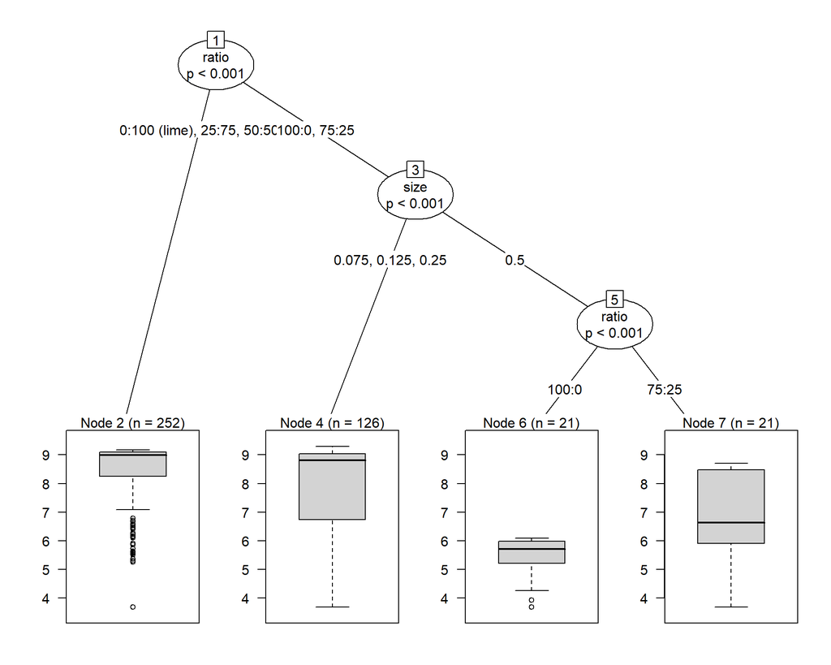

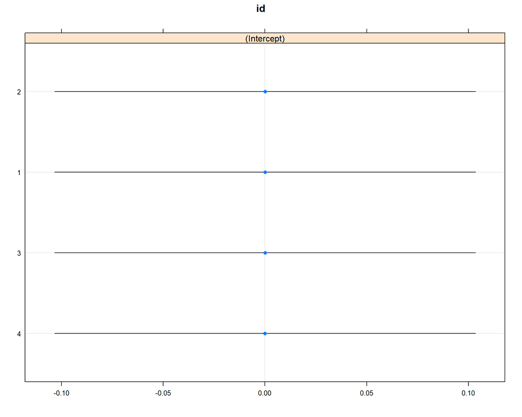

```r
tree <- lmertree(ph_level ~ 1|time + size + ratio + (1|id)|size + ratio, data=ph_data)
plot(tree)
```

Looking at this decision tree based on the model and data, we can see different outcomes or pH level depending on the particle size and ratio of waste limestone to lime that we choose.

For example, if we pick either the treatment ratios of 100:0 and 75:25 and then choose the particle size to be 0.5mm we can either end at node 6 or node 7 depending on the treatment ratio that we decide to use at the end. We can also work backwards and decide that we want our pH level to be be concentrated around the values of 5 to 6 the we can choose a 100:0 ratio of waste limestone and set the particle size to be 0.5.

# Iron Content Analysis

```r
iron.aov <- aov(iron_content ~ ratio + size, data=iron_data)
summary(iron.aov)
```

```
##             Df   Sum Sq  Mean Sq F value Pr(>F)
## ratio        4 0.003676 0.000919   0.270   0.89
## size         3 0.006875 0.002292   0.673   0.59
## Residuals    9 0.030625 0.003403
```

For this anova, we only investigate the main effects of the ratio and size variables. As we can see from the results of this analysis, none of the ratio and size variables significantly affect the iron which means that there is no difference between the effects of each variable levels on the iron content in the AMD. For this, we will not be doing any further analysis on the iron content.